# Estradiol & Progesterone Gene Expression Prediction — Subclass

Sneha M. Chaturvedi, Emma Jones

Last updated 2026-09-04

Estradiol and progesterone–gene limma-voom at the subclass-level annotation.

| **Inputs** | `data/cache/pb_base_subclass.rds`, `doc/targeted/targeted_hormones.xlsx` |
| --- | --- |
| **Outputs** | `results/gene-hormone/estradiol_genes_subclass/`, `results/gene-hormone/progesterone_genes_subclass/` |
| **Upstream** | `prep_data.R` |
| **Downstream** | None |

## Goals

Identify genes whose pseudobulk expression is predicted by estradiol (E2) and progesterone (P4) concentration, by **subclass**. Both hormones are analyzed **sex-combined**: XX and XY samples are pooled, with Sex optionally included as an additive covariate.

**Four models tested per hormone:**

- **Base** — `~ hormone`
- **Base + Sex** — `~ hormone + Sex`
- **Base + Batch** — `~ hormone + batch1_frac`
- **Base + Sex + Batch** — `~ hormone + Sex + batch1_frac`

Drops groups where fewer than 2 sexes are present after hormone filtering

## Set Up

- Load packages

```r
    Packages <- c(
      "tidyverse", "Seurat", "Signac", "glue", "readxl", "cowplot",
      "edgeR", "limma", "patchwork", "svglite", "Matrix", "ggpubr"
    )
    lapply(Packages, library, character.only = TRUE)

    source("pseudobulk_functions.R")
root <- find_project_root()

    set.seed(123)
```

- Load data

```r
    SSD_data <- readRDS(file.path(root, "data/cache/SSD_meta_umap.rds"))
    pb_base  <- readRDS(file.path(root, "data/cache/pb_base_subclass.rds"))
    targeted_comparison_raw <- read_xlsx(file.path(root, "doc/targeted/targeted_hormones.xlsx"))
    targeted_comparison_raw$E2 <- targeted_comparison_raw$`17B-E2 (ng/mL)`
    targeted_comparison_raw$TT <- targeted_comparison_raw$`TT (ng/mL)`
    targeted_comparison_raw$P4 <- targeted_comparison_raw$`P4 (ng/mL)`
```

- Configuration

```r
    celltype_col      <- "subclass"
    sample_col        <- "Sample"
    pb_sample_pattern <- "tissue\\d+"

    out_e2 <- file.path(root, "results/gene-hormone/estradiol_genes_subclass")
    out_p4 <- file.path(root, "results/gene-hormone/progesterone_genes_subclass")

    for (sub in c("run_voom_lm", "run_voom_lm_sex",
                  "run_voom_lm_batch", "run_voom_lm_sex_batch")) {
      dir.create(file.path(out_e2, sub), recursive = TRUE, showWarnings = FALSE)
      dir.create(file.path(out_p4, sub), recursive = TRUE, showWarnings = FALSE)
    }
```

```r
dirs <- c(
  file.path(root, "results/gene-hormone/estradiol_genes_log10/run_voom_lm"),
  file.path(root, "results/gene-hormone/estradiol_genes_log10/run_voom_lm_sex"),
  file.path(root, "results/gene-hormone/estradiol_genes_log10/run_voom_lm_batch"),
  file.path(root, "results/gene-hormone/estradiol_genes_log10/run_voom_lm_sex_batch"),
  file.path(root, "results/gene-hormone/progesterone_genes_log10/run_voom_lm"),
  file.path(root, "results/gene-hormone/progesterone_genes_log10/run_voom_lm_sex"),
  file.path(root, "results/gene-hormone/progesterone_genes_log10/run_voom_lm_batch"),
  file.path(root, "results/gene-hormone/progesterone_genes_log10/run_voom_lm_sex_batch")
)
purrr::walk(dirs, dir.create, recursive = TRUE, showWarnings = FALSE)
```

## Outlier Removal

Samples with hormone > Q3 + 1.5 × IQR are excluded per hormone before pseudobulk construction.

```r
detect_outliers <- function(data, variable) {
  outlier_limit <- quantile(data[[variable]], 0.75, na.rm = TRUE) +
    1.5 * IQR(data[[variable]], na.rm = TRUE)
  data %>% dplyr::filter(.data[[variable]] <= outlier_limit)
}

targeted_comparison_filtered_E2 <- detect_outliers(targeted_comparison_raw, "E2")
targeted_comparison_filtered_P4 <- detect_outliers(targeted_comparison_raw, "P4")

cat(
  "E2 — before:", nrow(targeted_comparison_raw),
  "  after:", nrow(targeted_comparison_filtered_E2), "\n"
)
```

```
## E2 — before: 46   after: 41
```

```r
cat(
  "P4 — before:", nrow(targeted_comparison_raw),
  "  after:", nrow(targeted_comparison_filtered_P4), "\n"
)
```

```
## P4 — before: 46   after: 41
```

```r
cat("E2 range after filtering:      ",
    paste(round(range(targeted_comparison_filtered_E2$E2, na.rm = TRUE), 3),
          collapse = " – "), "ng/mL\n")
```

```
## E2 range after filtering:       0.03 – 3.266 ng/mL
```

```r
cat("P4 range after filtering:      ",
    paste(round(range(targeted_comparison_filtered_P4$P4, na.rm = TRUE), 3),
          collapse = " – "), "ng/mL\n")
```

```
## P4 range after filtering:       2.47 – 29.781 ng/mL
```

```r
outliers_E2 <- dplyr::anti_join(targeted_comparison_raw,
                                targeted_comparison_filtered_E2, by = "Sample")
outliers_P4 <- dplyr::anti_join(targeted_comparison_raw,
                                targeted_comparison_filtered_P4, by = "Sample")

cat("E2 outliers removed:",
    if (nrow(outliers_E2)) paste(outliers_E2$Sample, collapse = ", ") else "none", "\n")
```

```
## E2 outliers removed: 7, 17, 31, 33, 38
```

```r
cat("P4 outliers removed:",
    if (nrow(outliers_P4)) paste(outliers_P4$Sample, collapse = ", ") else "none", "\n")
```

```
## P4 outliers removed: 17, 31, 33, 35, 39
```

## Pseudobulk

Min 30 cells per (sample × subclass) for inclusion. `add_batch_fraction()` computes the fraction of batch1 cells per biological sample and joins it onto the pseudobulk metadata for each hormone.

```r
pb_E2 <- merge_hormone_metadata(
  pb_base, targeted_comparison_filtered_E2,
  pb_sample_pattern = pb_sample_pattern, min_cells = 30
) %>% add_batch_fraction(SSD_data)

pb_P4 <- merge_hormone_metadata(
  pb_base, targeted_comparison_filtered_P4,
  pb_sample_pattern = pb_sample_pattern, min_cells = 30
) %>% add_batch_fraction(SSD_data)

cat(
  "E2 pseudobulk samples:", nrow(pb_E2$metadata),
  "  NAs in batch1_frac:", sum(is.na(pb_E2$metadata$batch1_frac)), "\n"
)
```

```
## E2 pseudobulk samples: 276   NAs in batch1_frac: 0
```

```r
cat("E2 batch1_frac summary:\n")
```

```
## E2 batch1_frac summary:
```

```r
print(summary(pb_E2$metadata$batch1_frac))
```

```
##    Min. 1st Qu.  Median    Mean 3rd Qu.    Max.
##  0.0000  0.2121  0.3835  0.4158  0.5787  1.0000
```

```r
cat(
  "P4 pseudobulk samples:", nrow(pb_P4$metadata),
  "  NAs in batch1_frac:", sum(is.na(pb_P4$metadata$batch1_frac)), "\n"
)
```

```
## P4 pseudobulk samples: 276   NAs in batch1_frac: 0
```

```r
cat("P4 batch1_frac summary:\n")
```

```
## P4 batch1_frac summary:
```

```r
print(summary(pb_P4$metadata$batch1_frac))
```

```
##    Min. 1st Qu.  Median    Mean 3rd Qu.    Max.
##  0.0000  0.2121  0.3835  0.4124  0.5787  1.0000
```

## Models

| Model | Formula | Notes |
| --- | --- | --- |
| Base | `~ hormone` | Combined-sample estimate; no adjustment |
| Base + Sex | `~ hormone + Sex` | Controls for sex-linked expression differences |
| Base + Batch | `~ hormone + batch1_frac` | Batch1 fraction per sample (continuous); absorbs residual batch composition differences |
| Base + Sex + Batch | `~ hormone + Sex + batch1_frac` | Both adjustments |

## Estradiol

### Base

`~ E2` — sex-combined, no covariates.

```r
res_E2_base <- analyze_hormone_combined(
  pb_E2$counts, pb_E2$metadata,
  hormone = "E2", model = run_voom_lm, min_samples = 21
)
```

```
##
## Group: Astrocyte
## Initial number of samples: 24
## Min samples required (fixed floor): 21
## Genes passing manual filter: 17933
## Samples with non-zero hormone: 24
## Final sample size: 24
##
## Group: Cajal-Retzius cell
## Initial number of samples: 5
## Min samples required (fixed floor): 21
## Genes passing manual filter: 8807
## Samples with non-zero hormone: 5
## Group removed: insufficient non-zero hormone values 5
##
## Group: EN-DL
## Initial number of samples: 36
## Min samples required (fixed floor): 21
## Genes passing manual filter: 28947
## Samples with non-zero hormone: 36
## Final sample size: 36
##
## Group: EN-Newborn
## Initial number of samples: 38
## Min samples required (fixed floor): 21
## Genes passing manual filter: 26196
## Samples with non-zero hormone: 38
## Final sample size: 38
##
## Group: EN-UL
## Initial number of samples: 35
## Min samples required (fixed floor): 21
## Genes passing manual filter: 27792
## Samples with non-zero hormone: 35
## Final sample size: 35
##
## Group: IN-CGE
## Initial number of samples: 34
## Min samples required (fixed floor): 21
## Genes passing manual filter: 19338
```

[output cut: 34 more lines]

```
## Samples with non-zero hormone: 18
## Group removed: insufficient non-zero hormone values 18
##
## Group: Radial glia
## Initial number of samples: 18
## Min samples required (fixed floor): 21
## Genes passing manual filter: 17603
## Samples with non-zero hormone: 18
## Group removed: insufficient non-zero hormone values 18
##
## Group: Vascular
## Initial number of samples: 1
## Min samples required (fixed floor): 21
## Genes passing manual filter: 0
## Group removed: no genes passed the filter
```

```r
summary_E2_base <- summarize_sig_genes(res_E2_base$combined_results)

plot_top_genes_from_subsets(
  res_E2_base$by_group_data,
  output_dir = file.path(out_e2, "run_voom_lm"),
  hormone    = "E2"
)
```

```
## Number of groups to plot: 7
```

```
##  Plotting group: Astrocyte_combined
```

```
## - Significant genes (FDR < 0.1, |logFC| >= 0.25): 0
```

```
## No valid plots for group
```

```
##  Plotting group: EN-DL_combined
```

```
## - Significant genes (FDR < 0.1, |logFC| >= 0.25): 0
```

```
## No valid plots for group
```

```
##  Plotting group: EN-Newborn_combined
```

```
## - Significant genes (FDR < 0.1, |logFC| >= 0.25): 0
```

```
## No valid plots for group
```

```
##  Plotting group: EN-UL_combined
```

```
## - Significant genes (FDR < 0.1, |logFC| >= 0.25): 0
```

```
## No valid plots for group
```

```
##  Plotting group: IN-CGE_combined
```

```
## - Significant genes (FDR < 0.1, |logFC| >= 0.25): 0
```

```
## No valid plots for group
```

```
##  Plotting group: IN-MGE_combined
```

```
## - Significant genes (FDR < 0.1, |logFC| >= 0.25): 1
```

```
##     Plotting gene: ENSG00000286797 (adj. p-value: 0.0423)
```

```
## Saved: IN-MGE_combined_top_genes.png  +  svg/IN-MGE_combined_top_genes.svg
##   Saved plot for IN-MGE_combined
##  Plotting group: IPC-EN_combined
## - Significant genes (FDR < 0.1, |logFC| >= 0.25): 0
## No valid plots for group
```

```r
save_dual_format(
  plot_sig_gene_summary(summary_E2_base, "E2 — Base (~ E2) | Subclass"),
  output_dir    = file.path(out_e2, "run_voom_lm"),
  filename_base = "E2_base_sig_gene_summary"
)
```

```
## Saved: E2_base_sig_gene_summary.png  +  svg/E2_base_sig_gene_summary.svg
```

```r
write_csv(
  res_E2_base$combined_results,
  file.path(out_e2, "run_voom_lm", "E2_base_results.csv")
)
write_csv(
  summary_E2_base,
  file.path(out_e2, "run_voom_lm", "E2_base_summary.csv")
)
```

#### Significant Genes

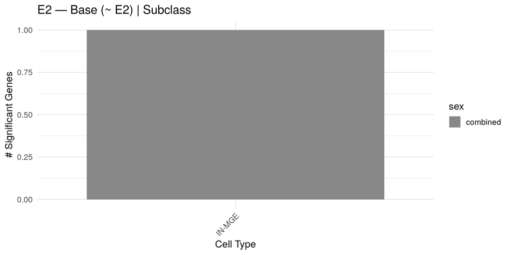

```r
plot_sig_gene_summary(summary_E2_base, "E2 — Base (~ E2) | Subclass")
```

#### Top Results

```r
res_E2_base$combined_results %>%
  dplyr::arrange(adj.P.Val) %>%
  dplyr::select(gene, cell_type, sex, logFC, adj.P.Val) %>%
  head(10) %>%
  knitr::kable(digits = 4, caption = "Top 10 hits — E2 Base")
```

Top 10 hits — E2 Base

| gene | cell_type | sex | logFC | adj.P.Val |
| --- | --- | --- | --- | --- |
| ENSG00000286797 | IN-MGE | combined | 1.7006 | 0.0423 |
| FSIP2 | IN-MGE | combined | 1.0192 | 0.1265 |
| FSIP2 | EN-UL | combined | 0.8221 | 0.3112 |
| ENSG00000286797 | EN-Newborn | combined | 1.4422 | 0.3687 |
| OR4F5 | EN-Newborn | combined | 0.1552 | 0.9997 |
| ENSG00000238009 | EN-Newborn | combined | -0.0072 | 0.9997 |
| ENSG00000241860 | EN-Newborn | combined | -0.1351 | 0.9997 |
| ENSG00000290385 | EN-Newborn | combined | 0.0414 | 0.9997 |
| ENSG00000291215 | EN-Newborn | combined | -0.0080 | 0.9997 |
| ENSG00000229905 | EN-Newborn | combined | 0.4026 | 0.9997 |

### Base + Sex

`~ E2 + Sex`

```r
res_E2_sex <- analyze_hormone_combined(
  pb_E2$counts, pb_E2$metadata,
  hormone = "E2", model = run_voom_lm_sex, min_samples = 21
)
```

```
##
## Group: Astrocyte
## Initial number of samples: 24
## Min samples required (fixed floor): 21
## Genes passing manual filter: 17933
## Samples with non-zero hormone: 24
## Final sample size: 24
##
## Group: Cajal-Retzius cell
## Initial number of samples: 5
## Min samples required (fixed floor): 21
## Genes passing manual filter: 8807
## Samples with non-zero hormone: 5
## Group removed: insufficient non-zero hormone values 5
##
## Group: EN-DL
## Initial number of samples: 36
## Min samples required (fixed floor): 21
## Genes passing manual filter: 28947
## Samples with non-zero hormone: 36
## Final sample size: 36
##
## Group: EN-Newborn
## Initial number of samples: 38
## Min samples required (fixed floor): 21
## Genes passing manual filter: 26196
## Samples with non-zero hormone: 38
## Final sample size: 38
##
## Group: EN-UL
## Initial number of samples: 35
## Min samples required (fixed floor): 21
## Genes passing manual filter: 27792
## Samples with non-zero hormone: 35
## Final sample size: 35
##
## Group: IN-CGE
## Initial number of samples: 34
## Min samples required (fixed floor): 21
## Genes passing manual filter: 19338
```

[output cut: 34 more lines]

```
## Samples with non-zero hormone: 18
## Group removed: insufficient non-zero hormone values 18
##
## Group: Radial glia
## Initial number of samples: 18
## Min samples required (fixed floor): 21
## Genes passing manual filter: 17603
## Samples with non-zero hormone: 18
## Group removed: insufficient non-zero hormone values 18
##
## Group: Vascular
## Initial number of samples: 1
## Min samples required (fixed floor): 21
## Genes passing manual filter: 0
## Group removed: no genes passed the filter
```

```r
summary_E2_sex <- summarize_sig_genes(res_E2_sex$combined_results)

plot_top_genes_from_subsets(
  res_E2_sex$by_group_data,
  output_dir = file.path(out_e2, "run_voom_lm_sex"),
  hormone    = "E2"
)
```

```
## Number of groups to plot: 7
```

```
##  Plotting group: Astrocyte_combined
```

```
## - Significant genes (FDR < 0.1, |logFC| >= 0.25): 0
```

```
## No valid plots for group
```

```
##  Plotting group: EN-DL_combined
```

```
## - Significant genes (FDR < 0.1, |logFC| >= 0.25): 0
```

```
## No valid plots for group
```

```
##  Plotting group: EN-Newborn_combined
```

```
## - Significant genes (FDR < 0.1, |logFC| >= 0.25): 0
```

```
## No valid plots for group
```

```
##  Plotting group: EN-UL_combined
```

```
## - Significant genes (FDR < 0.1, |logFC| >= 0.25): 0
```

```
## No valid plots for group
```

```
##  Plotting group: IN-CGE_combined
```

```
## - Significant genes (FDR < 0.1, |logFC| >= 0.25): 0
```

```
## No valid plots for group
```

```
##  Plotting group: IN-MGE_combined
```

```
## - Significant genes (FDR < 0.1, |logFC| >= 0.25): 1
```

```
##     Plotting gene: ENSG00000286797 (adj. p-value: 0.0413)
```

```
## Saved: IN-MGE_combined_top_genes.png  +  svg/IN-MGE_combined_top_genes.svg
##   Saved plot for IN-MGE_combined
##  Plotting group: IPC-EN_combined
## - Significant genes (FDR < 0.1, |logFC| >= 0.25): 0
## No valid plots for group
```

```r
save_dual_format(
  plot_sig_gene_summary(summary_E2_sex, "E2 — Base + Sex (~ E2 + Sex) | Subclass"),
  output_dir    = file.path(out_e2, "run_voom_lm_sex"),
  filename_base = "E2_sex_sig_gene_summary"
)
```

```
## Saved: E2_sex_sig_gene_summary.png  +  svg/E2_sex_sig_gene_summary.svg
```

```r
write_csv(
  res_E2_sex$combined_results,
  file.path(out_e2, "run_voom_lm_sex", "E2_sex_results.csv")
)
write_csv(
  summary_E2_sex,
  file.path(out_e2, "run_voom_lm_sex", "E2_sex_summary.csv")
)
```

#### Significant Genes

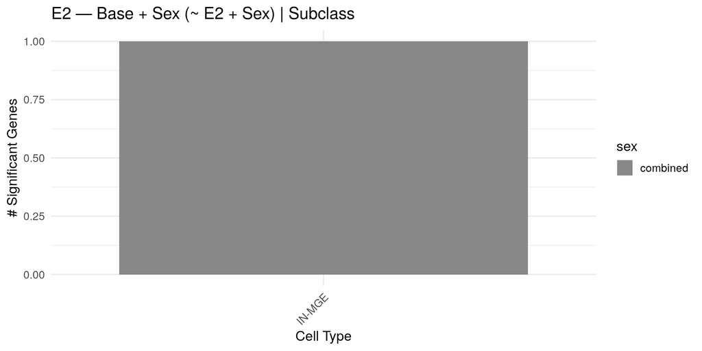

```r
plot_sig_gene_summary(summary_E2_sex, "E2 — Base + Sex (~ E2 + Sex) | Subclass")
```

#### Top Results

```r
res_E2_sex$combined_results %>%
  dplyr::arrange(adj.P.Val) %>%
  dplyr::select(gene, cell_type, sex, logFC, adj.P.Val) %>%
  head(10) %>%
  knitr::kable(digits = 4, caption = "Top 10 hits — E2 Base + Sex")
```

Top 10 hits — E2 Base + Sex

| gene | cell_type | sex | logFC | adj.P.Val |
| --- | --- | --- | --- | --- |
| ENSG00000286797 | IN-MGE | combined | 1.6569 | 0.0413 |
| FSIP2 | IN-MGE | combined | 1.0074 | 0.1755 |
| FSIP2 | EN-UL | combined | 0.8255 | 0.3491 |
| ENSG00000286797 | EN-Newborn | combined | 1.3025 | 0.9892 |
| ENSG00000241860 | Astrocyte | combined | -0.3467 | 0.9995 |
| ENSG00000291215 | Astrocyte | combined | -0.1670 | 0.9995 |
| LINC01409 | Astrocyte | combined | -0.3748 | 0.9995 |
| ENSG00000290784 | Astrocyte | combined | -0.3788 | 0.9995 |
| LINC00115 | Astrocyte | combined | 0.1270 | 0.9995 |
| LINC01128 | Astrocyte | combined | 0.3931 | 0.9995 |

### Base + Batch

`~ E2 + batch1_frac`

```r
res_E2_batch <- analyze_hormone_combined(
  pb_E2$counts, pb_E2$metadata,
  hormone = "E2", model = run_voom_lm_batch, min_samples = 21
)
```

```
##
## Group: Astrocyte
## Initial number of samples: 24
## Min samples required (fixed floor): 21
## Genes passing manual filter: 17933
## Samples with non-zero hormone: 24
## Final sample size: 24
##
## Group: Cajal-Retzius cell
## Initial number of samples: 5
## Min samples required (fixed floor): 21
## Genes passing manual filter: 8807
## Samples with non-zero hormone: 5
## Group removed: insufficient non-zero hormone values 5
##
## Group: EN-DL
## Initial number of samples: 36
## Min samples required (fixed floor): 21
## Genes passing manual filter: 28947
## Samples with non-zero hormone: 36
## Final sample size: 36
##
## Group: EN-Newborn
## Initial number of samples: 38
## Min samples required (fixed floor): 21
## Genes passing manual filter: 26196
## Samples with non-zero hormone: 38
## Final sample size: 38
##
## Group: EN-UL
## Initial number of samples: 35
## Min samples required (fixed floor): 21
## Genes passing manual filter: 27792
## Samples with non-zero hormone: 35
## Final sample size: 35
##
## Group: IN-CGE
## Initial number of samples: 34
## Min samples required (fixed floor): 21
## Genes passing manual filter: 19338
```

[output cut: 34 more lines]

```
## Samples with non-zero hormone: 18
## Group removed: insufficient non-zero hormone values 18
##
## Group: Radial glia
## Initial number of samples: 18
## Min samples required (fixed floor): 21
## Genes passing manual filter: 17603
## Samples with non-zero hormone: 18
## Group removed: insufficient non-zero hormone values 18
##
## Group: Vascular
## Initial number of samples: 1
## Min samples required (fixed floor): 21
## Genes passing manual filter: 0
## Group removed: no genes passed the filter
```

```r
summary_E2_batch <- summarize_sig_genes(res_E2_batch$combined_results)

plot_top_genes_from_subsets(
  res_E2_batch$by_group_data,
  output_dir = file.path(out_e2, "run_voom_lm_batch"),
  hormone    = "E2"
)
```

```
## Number of groups to plot: 7
```

```
##  Plotting group: Astrocyte_combined
```

```
## - Significant genes (FDR < 0.1, |logFC| >= 0.25): 0
```

```
## No valid plots for group
```

```
##  Plotting group: EN-DL_combined
```

```
## - Significant genes (FDR < 0.1, |logFC| >= 0.25): 0
```

```
## No valid plots for group
```

```
##  Plotting group: EN-Newborn_combined
```

```
## - Significant genes (FDR < 0.1, |logFC| >= 0.25): 0
```

```
## No valid plots for group
```

```
##  Plotting group: EN-UL_combined
```

```
## - Significant genes (FDR < 0.1, |logFC| >= 0.25): 0
```

```
## No valid plots for group
```

```
##  Plotting group: IN-CGE_combined
```

```
## - Significant genes (FDR < 0.1, |logFC| >= 0.25): 0
```

```
## No valid plots for group
```

```
##  Plotting group: IN-MGE_combined
```

```
## - Significant genes (FDR < 0.1, |logFC| >= 0.25): 1
```

```
##     Plotting gene: ENSG00000286797 (adj. p-value: 0.0187)
```

```
## Saved: IN-MGE_combined_top_genes.png  +  svg/IN-MGE_combined_top_genes.svg
##   Saved plot for IN-MGE_combined
##  Plotting group: IPC-EN_combined
## - Significant genes (FDR < 0.1, |logFC| >= 0.25): 0
## No valid plots for group
```

```r
save_dual_format(
  plot_sig_gene_summary(summary_E2_batch, "E2 — Base + Batch (~ E2 + batch1_frac) | Subclass"),
  output_dir    = file.path(out_e2, "run_voom_lm_batch"),
  filename_base = "E2_batch_sig_gene_summary"
)
```

```
## Saved: E2_batch_sig_gene_summary.png  +  svg/E2_batch_sig_gene_summary.svg
```

```r
write_csv(
  res_E2_batch$combined_results,
  file.path(out_e2, "run_voom_lm_batch", "E2_batch_results.csv")
)
write_csv(
  summary_E2_batch,
  file.path(out_e2, "run_voom_lm_batch", "E2_batch_summary.csv")
)
```

#### Significant Genes

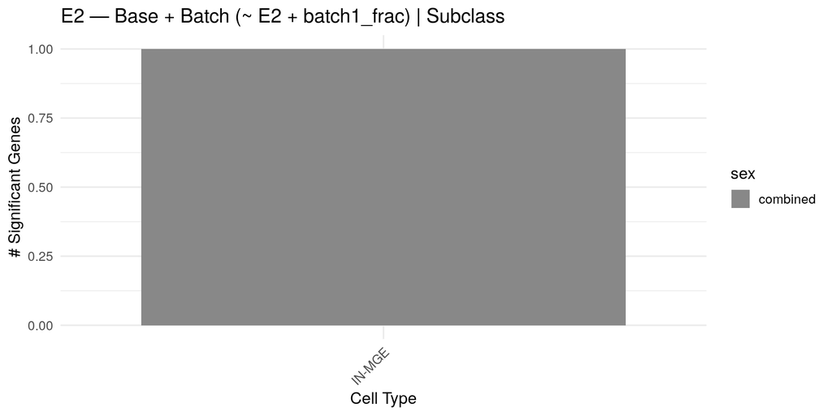

```r
plot_sig_gene_summary(summary_E2_batch, "E2 — Base + Batch (~ E2 + batch1_frac) | Subclass")
```

#### Top Results

```r
res_E2_batch$combined_results %>%
  dplyr::arrange(adj.P.Val) %>%
  dplyr::select(gene, cell_type, sex, logFC, adj.P.Val) %>%
  head(10) %>%
  knitr::kable(digits = 4, caption = "Top 10 hits — E2 Base + Batch")
```

Top 10 hits — E2 Base + Batch

| gene | cell_type | sex | logFC | adj.P.Val |
| --- | --- | --- | --- | --- |
| ENSG00000286797 | IN-MGE | combined | 1.6960 | 0.0187 |
| FSIP2 | IN-MGE | combined | 1.0154 | 0.1661 |
| ACOXL | EN-UL | combined | 0.8455 | 0.6044 |
| FSIP2 | EN-UL | combined | 0.8032 | 0.6044 |
| SGO1-AS1 | EN-UL | combined | -1.0228 | 0.6653 |
| EPHB1 | EN-UL | combined | 0.4150 | 0.6653 |
| DCLK2 | EN-UL | combined | -0.4225 | 0.6653 |
| ENSG00000253796 | EN-UL | combined | -0.5313 | 0.6653 |
| TGFB3 | EN-UL | combined | 0.8660 | 0.6653 |
| ENSG00000286797 | EN-Newborn | combined | 1.3522 | 0.6727 |

### Base + Sex + Batch

`~ E2 + Sex + batch1_frac`

```r
res_E2_sex_batch <- analyze_hormone_combined(
  pb_E2$counts, pb_E2$metadata,
  hormone = "E2", model = run_voom_lm_sex_batch, min_samples = 21
)
```

```
##
## Group: Astrocyte
## Initial number of samples: 24
## Min samples required (fixed floor): 21
## Genes passing manual filter: 17933
## Samples with non-zero hormone: 24
## Final sample size: 24
##
## Group: Cajal-Retzius cell
## Initial number of samples: 5
## Min samples required (fixed floor): 21
## Genes passing manual filter: 8807
## Samples with non-zero hormone: 5
## Group removed: insufficient non-zero hormone values 5
##
## Group: EN-DL
## Initial number of samples: 36
## Min samples required (fixed floor): 21
## Genes passing manual filter: 28947
## Samples with non-zero hormone: 36
## Final sample size: 36
##
## Group: EN-Newborn
## Initial number of samples: 38
## Min samples required (fixed floor): 21
## Genes passing manual filter: 26196
## Samples with non-zero hormone: 38
## Final sample size: 38
##
## Group: EN-UL
## Initial number of samples: 35
## Min samples required (fixed floor): 21
## Genes passing manual filter: 27792
## Samples with non-zero hormone: 35
## Final sample size: 35
##
## Group: IN-CGE
## Initial number of samples: 34
## Min samples required (fixed floor): 21
## Genes passing manual filter: 19338
```

[output cut: 34 more lines]

```
## Samples with non-zero hormone: 18
## Group removed: insufficient non-zero hormone values 18
##
## Group: Radial glia
## Initial number of samples: 18
## Min samples required (fixed floor): 21
## Genes passing manual filter: 17603
## Samples with non-zero hormone: 18
## Group removed: insufficient non-zero hormone values 18
##
## Group: Vascular
## Initial number of samples: 1
## Min samples required (fixed floor): 21
## Genes passing manual filter: 0
## Group removed: no genes passed the filter
```

```r
summary_E2_sex_batch <- summarize_sig_genes(res_E2_sex_batch$combined_results)

plot_top_genes_from_subsets(
  res_E2_sex_batch$by_group_data,
  output_dir = file.path(out_e2, "run_voom_lm_sex_batch"),
  hormone    = "E2"
)
```

```
## Number of groups to plot: 7
```

```
##  Plotting group: Astrocyte_combined
```

```
## - Significant genes (FDR < 0.1, |logFC| >= 0.25): 0
```

```
## No valid plots for group
```

```
##  Plotting group: EN-DL_combined
```

```
## - Significant genes (FDR < 0.1, |logFC| >= 0.25): 0
```

```
## No valid plots for group
```

```
##  Plotting group: EN-Newborn_combined
```

```
## - Significant genes (FDR < 0.1, |logFC| >= 0.25): 0
```

```
## No valid plots for group
```

```
##  Plotting group: EN-UL_combined
```

```
## - Significant genes (FDR < 0.1, |logFC| >= 0.25): 0
```

```
## No valid plots for group
```

```
##  Plotting group: IN-CGE_combined
```

```
## - Significant genes (FDR < 0.1, |logFC| >= 0.25): 0
```

```
## No valid plots for group
```

```
##  Plotting group: IN-MGE_combined
```

```
## - Significant genes (FDR < 0.1, |logFC| >= 0.25): 1
```

```
##     Plotting gene: ENSG00000286797 (adj. p-value: 0.0229)
```

```
## Saved: IN-MGE_combined_top_genes.png  +  svg/IN-MGE_combined_top_genes.svg
##   Saved plot for IN-MGE_combined
##  Plotting group: IPC-EN_combined
## - Significant genes (FDR < 0.1, |logFC| >= 0.25): 0
## No valid plots for group
```

```r
save_dual_format(
  plot_sig_gene_summary(
    summary_E2_sex_batch,
    "E2 — Base + Sex + Batch (~ E2 + Sex + batch1_frac) | Subclass"
  ),
  output_dir    = file.path(out_e2, "run_voom_lm_sex_batch"),
  filename_base = "E2_sex_batch_sig_gene_summary"
)
```

```
## Saved: E2_sex_batch_sig_gene_summary.png  +  svg/E2_sex_batch_sig_gene_summary.svg
```

```r
write_csv(
  res_E2_sex_batch$combined_results,
  file.path(out_e2, "run_voom_lm_sex_batch", "E2_sex_batch_results.csv")
)
write_csv(
  summary_E2_sex_batch,
  file.path(out_e2, "run_voom_lm_sex_batch", "E2_sex_batch_summary.csv")
)
```

#### Significant Genes

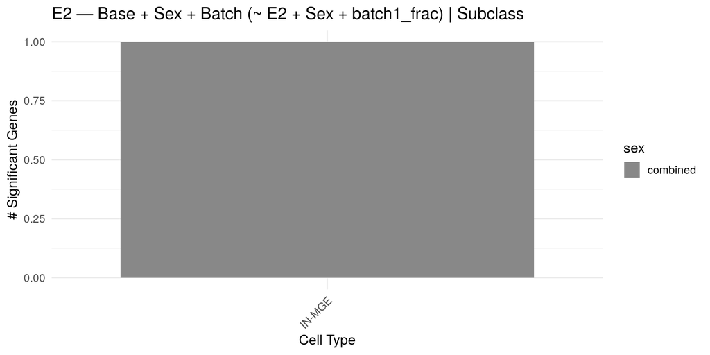

```r
plot_sig_gene_summary(
  summary_E2_sex_batch,
  "E2 — Base + Sex + Batch (~ E2 + Sex + batch1_frac) | Subclass"
)
```

#### Top Results

```r
res_E2_sex_batch$combined_results %>%
  dplyr::arrange(adj.P.Val) %>%
  dplyr::select(gene, cell_type, sex, logFC, adj.P.Val) %>%
  head(10) %>%
  knitr::kable(digits = 4, caption = "Top 10 hits — E2 Base + Sex + Batch")
```

Top 10 hits — E2 Base + Sex + Batch

| gene | cell_type | sex | logFC | adj.P.Val |
| --- | --- | --- | --- | --- |
| ENSG00000286797 | IN-MGE | combined | 1.6465 | 0.0229 |
| FSIP2 | IN-MGE | combined | 1.0049 | 0.2199 |
| FSIP2 | EN-UL | combined | 0.8095 | 0.7467 |
| ACOXL | EN-UL | combined | 0.8269 | 0.8293 |
| SGO1-AS1 | EN-UL | combined | -1.0171 | 0.8293 |
| EPHB1 | EN-UL | combined | 0.4141 | 0.8293 |
| DCLK2 | EN-UL | combined | -0.4248 | 0.8293 |
| ENSG00000253796 | EN-UL | combined | -0.5344 | 0.8293 |
| TGFB3 | EN-UL | combined | 0.8450 | 0.8293 |
| ENSG00000286797 | EN-UL | combined | 1.3060 | 0.9368 |

## Progesterone

### Base

`~ P4` — sex-combined, no covariates.

```r
res_P4_base <- analyze_hormone_combined(
  pb_P4$counts, pb_P4$metadata,
  hormone = "P4", model = run_voom_lm, min_samples = 21
)
```

```
##
## Group: Astrocyte
## Initial number of samples: 24
## Min samples required (fixed floor): 21
## Genes passing manual filter: 18233
## Samples with non-zero hormone: 24
## Final sample size: 24
##
## Group: Cajal-Retzius cell
## Initial number of samples: 6
## Min samples required (fixed floor): 21
## Genes passing manual filter: 10810
## Samples with non-zero hormone: 6
## Group removed: insufficient non-zero hormone values 6
##
## Group: EN-DL
## Initial number of samples: 36
## Min samples required (fixed floor): 21
## Genes passing manual filter: 29023
## Samples with non-zero hormone: 36
## Final sample size: 36
##
## Group: EN-Newborn
## Initial number of samples: 37
## Min samples required (fixed floor): 21
## Genes passing manual filter: 26036
## Samples with non-zero hormone: 37
## Final sample size: 37
##
## Group: EN-UL
## Initial number of samples: 35
## Min samples required (fixed floor): 21
## Genes passing manual filter: 27735
## Samples with non-zero hormone: 35
## Final sample size: 35
##
## Group: IN-CGE
## Initial number of samples: 34
## Min samples required (fixed floor): 21
## Genes passing manual filter: 19714
```

[output cut: 34 more lines]

```
## Samples with non-zero hormone: 18
## Group removed: insufficient non-zero hormone values 18
##
## Group: Radial glia
## Initial number of samples: 17
## Min samples required (fixed floor): 21
## Genes passing manual filter: 17395
## Samples with non-zero hormone: 17
## Group removed: insufficient non-zero hormone values 17
##
## Group: Vascular
## Initial number of samples: 1
## Min samples required (fixed floor): 21
## Genes passing manual filter: 0
## Group removed: no genes passed the filter
```

```r
summary_P4_base <- summarize_sig_genes(res_P4_base$combined_results)

plot_top_genes_from_subsets(
  res_P4_base$by_group_data,
  output_dir = file.path(out_p4, "run_voom_lm"),
  hormone    = "P4"
)
```

```
## Number of groups to plot: 7
```

```
##  Plotting group: Astrocyte_combined
```

```
## - Significant genes (FDR < 0.1, |logFC| >= 0.25): 0
```

```
## No valid plots for group
```

```
##  Plotting group: EN-DL_combined
```

```
## - Significant genes (FDR < 0.1, |logFC| >= 0.25): 0
```

```
## No valid plots for group
```

```
##  Plotting group: EN-Newborn_combined
```

```
## - Significant genes (FDR < 0.1, |logFC| >= 0.25): 0
```

```
## No valid plots for group
```

```
##  Plotting group: EN-UL_combined
```

```
## - Significant genes (FDR < 0.1, |logFC| >= 0.25): 0
```

```
## No valid plots for group
```

```
##  Plotting group: IN-CGE_combined
```

```
## - Significant genes (FDR < 0.1, |logFC| >= 0.25): 0
```

```
## No valid plots for group
```

```
##  Plotting group: IN-MGE_combined
```

```
## - Significant genes (FDR < 0.1, |logFC| >= 0.25): 0
```

```
## No valid plots for group
```

```
##  Plotting group: IPC-EN_combined
```

```
## - Significant genes (FDR < 0.1, |logFC| >= 0.25): 0
```

```
## No valid plots for group
```

```r
save_dual_format(
  plot_sig_gene_summary(summary_P4_base, "P4 — Base (~ P4) | Subclass"),
  output_dir    = file.path(out_p4, "run_voom_lm"),
  filename_base = "P4_base_sig_gene_summary"
)
```

```
## Saved: P4_base_sig_gene_summary.png  +  svg/P4_base_sig_gene_summary.svg
```

```r
write_csv(
  res_P4_base$combined_results,
  file.path(out_p4, "run_voom_lm", "P4_base_results.csv")
)
write_csv(
  summary_P4_base,
  file.path(out_p4, "run_voom_lm", "P4_base_summary.csv")
)
```

#### Significant Genes

[figure not shown]

```r
plot_sig_gene_summary(summary_P4_base, "P4 — Base (~ P4) | Subclass")
```

#### Top Results

```r
res_P4_base$combined_results %>%
  dplyr::arrange(adj.P.Val) %>%
  dplyr::select(gene, cell_type, sex, logFC, adj.P.Val) %>%
  head(10) %>%
  knitr::kable(digits = 4, caption = "Top 10 hits — P4 Base")
```

Top 10 hits — P4 Base

| gene | cell_type | sex | logFC | adj.P.Val |
| --- | --- | --- | --- | --- |
| BGLAP | EN-UL | combined | -0.1318 | 0.0021 |
| PLEKHA5 | EN-UL | combined | 0.0359 | 0.0021 |
| FAHD1 | EN-UL | combined | -0.0578 | 0.0021 |
| CBR3 | EN-UL | combined | -0.1229 | 0.0021 |
| GRM3 | EN-DL | combined | 0.0498 | 0.0023 |
| DISP3 | EN-UL | combined | -0.0565 | 0.0025 |
| DCAF6 | EN-UL | combined | 0.0268 | 0.0025 |
| TXNDC15 | EN-UL | combined | -0.0477 | 0.0025 |
| LMAN2 | EN-UL | combined | -0.0548 | 0.0025 |
| GRIP1 | EN-UL | combined | 0.0300 | 0.0025 |

### Base + Sex

`~ P4 + Sex`

```r
res_P4_sex <- analyze_hormone_combined(
  pb_P4$counts, pb_P4$metadata,
  hormone = "P4", model = run_voom_lm_sex, min_samples = 21
)
```

```
##
## Group: Astrocyte
## Initial number of samples: 24
## Min samples required (fixed floor): 21
## Genes passing manual filter: 18233
## Samples with non-zero hormone: 24
## Final sample size: 24
##
## Group: Cajal-Retzius cell
## Initial number of samples: 6
## Min samples required (fixed floor): 21
## Genes passing manual filter: 10810
## Samples with non-zero hormone: 6
## Group removed: insufficient non-zero hormone values 6
##
## Group: EN-DL
## Initial number of samples: 36
## Min samples required (fixed floor): 21
## Genes passing manual filter: 29023
## Samples with non-zero hormone: 36
## Final sample size: 36
##
## Group: EN-Newborn
## Initial number of samples: 37
## Min samples required (fixed floor): 21
## Genes passing manual filter: 26036
## Samples with non-zero hormone: 37
## Final sample size: 37
##
## Group: EN-UL
## Initial number of samples: 35
## Min samples required (fixed floor): 21
## Genes passing manual filter: 27735
## Samples with non-zero hormone: 35
## Final sample size: 35
##
## Group: IN-CGE
## Initial number of samples: 34
## Min samples required (fixed floor): 21
## Genes passing manual filter: 19714
```

[output cut: 34 more lines]

```
## Samples with non-zero hormone: 18
## Group removed: insufficient non-zero hormone values 18
##
## Group: Radial glia
## Initial number of samples: 17
## Min samples required (fixed floor): 21
## Genes passing manual filter: 17395
## Samples with non-zero hormone: 17
## Group removed: insufficient non-zero hormone values 17
##
## Group: Vascular
## Initial number of samples: 1
## Min samples required (fixed floor): 21
## Genes passing manual filter: 0
## Group removed: no genes passed the filter
```

```r
summary_P4_sex <- summarize_sig_genes(res_P4_sex$combined_results)

plot_top_genes_from_subsets(
  res_P4_sex$by_group_data,
  output_dir = file.path(out_p4, "run_voom_lm_sex"),
  hormone    = "P4"
)
```

```
## Number of groups to plot: 7
```

```
##  Plotting group: Astrocyte_combined
```

```
## - Significant genes (FDR < 0.1, |logFC| >= 0.25): 0
```

```
## No valid plots for group
```

```
##  Plotting group: EN-DL_combined
```

```
## - Significant genes (FDR < 0.1, |logFC| >= 0.25): 0
```

```
## No valid plots for group
```

```
##  Plotting group: EN-Newborn_combined
```

```
## - Significant genes (FDR < 0.1, |logFC| >= 0.25): 0
```

```
## No valid plots for group
```

```
##  Plotting group: EN-UL_combined
```

```
## - Significant genes (FDR < 0.1, |logFC| >= 0.25): 0
```

```
## No valid plots for group
```

```
##  Plotting group: IN-CGE_combined
```

```
## - Significant genes (FDR < 0.1, |logFC| >= 0.25): 0
```

```
## No valid plots for group
```

```
##  Plotting group: IN-MGE_combined
```

```
## - Significant genes (FDR < 0.1, |logFC| >= 0.25): 0
```

```
## No valid plots for group
```

```
##  Plotting group: IPC-EN_combined
```

```
## - Significant genes (FDR < 0.1, |logFC| >= 0.25): 0
```

```
## No valid plots for group
```

```r
save_dual_format(
  plot_sig_gene_summary(summary_P4_sex, "P4 — Base + Sex (~ P4 + Sex) | Subclass"),
  output_dir    = file.path(out_p4, "run_voom_lm_sex"),
  filename_base = "P4_sex_sig_gene_summary"
)
```

```
## Saved: P4_sex_sig_gene_summary.png  +  svg/P4_sex_sig_gene_summary.svg
```

```r
write_csv(
  res_P4_sex$combined_results,
  file.path(out_p4, "run_voom_lm_sex", "P4_sex_results.csv")
)
write_csv(
  summary_P4_sex,
  file.path(out_p4, "run_voom_lm_sex", "P4_sex_summary.csv")
)
```

#### Significant Genes

[figure not shown]

```r
plot_sig_gene_summary(summary_P4_sex, "P4 — Base + Sex (~ P4 + Sex) | Subclass")
```

#### Top Results

```r
res_P4_sex$combined_results %>%
  dplyr::arrange(adj.P.Val) %>%
  dplyr::select(gene, cell_type, sex, logFC, adj.P.Val) %>%
  head(10) %>%
  knitr::kable(digits = 4, caption = "Top 10 hits — P4 Base + Sex")
```

Top 10 hits — P4 Base + Sex

| gene | cell_type | sex | logFC | adj.P.Val |
| --- | --- | --- | --- | --- |
| CBR3 | EN-UL | combined | -0.1227 | 0.0013 |
| BGLAP | EN-UL | combined | -0.1320 | 0.0032 |
| TXNDC15 | EN-UL | combined | -0.0481 | 0.0032 |
| PLEKHA5 | EN-UL | combined | 0.0358 | 0.0032 |
| GRIP1 | EN-UL | combined | 0.0303 | 0.0032 |
| FAHD1 | EN-UL | combined | -0.0576 | 0.0032 |
| LINC00324 | EN-UL | combined | -0.1598 | 0.0032 |
| DCAF6 | EN-UL | combined | 0.0272 | 0.0035 |
| GRM3 | EN-DL | combined | 0.0491 | 0.0035 |
| FANCL | EN-DL | combined | 0.0332 | 0.0036 |

### Base + Batch

`~ P4 + batch1_frac`

```r
res_P4_batch <- analyze_hormone_combined(
  pb_P4$counts, pb_P4$metadata,
  hormone = "P4", model = run_voom_lm_batch, min_samples = 21
)
```

```
##
## Group: Astrocyte
## Initial number of samples: 24
## Min samples required (fixed floor): 21
## Genes passing manual filter: 18233
## Samples with non-zero hormone: 24
## Final sample size: 24
##
## Group: Cajal-Retzius cell
## Initial number of samples: 6
## Min samples required (fixed floor): 21
## Genes passing manual filter: 10810
## Samples with non-zero hormone: 6
## Group removed: insufficient non-zero hormone values 6
##
## Group: EN-DL
## Initial number of samples: 36
## Min samples required (fixed floor): 21
## Genes passing manual filter: 29023
## Samples with non-zero hormone: 36
## Final sample size: 36
##
## Group: EN-Newborn
## Initial number of samples: 37
## Min samples required (fixed floor): 21
## Genes passing manual filter: 26036
## Samples with non-zero hormone: 37
## Final sample size: 37
##
## Group: EN-UL
## Initial number of samples: 35
## Min samples required (fixed floor): 21
## Genes passing manual filter: 27735
## Samples with non-zero hormone: 35
## Final sample size: 35
##
## Group: IN-CGE
## Initial number of samples: 34
## Min samples required (fixed floor): 21
## Genes passing manual filter: 19714
```

[output cut: 34 more lines]

```
## Samples with non-zero hormone: 18
## Group removed: insufficient non-zero hormone values 18
##
## Group: Radial glia
## Initial number of samples: 17
## Min samples required (fixed floor): 21
## Genes passing manual filter: 17395
## Samples with non-zero hormone: 17
## Group removed: insufficient non-zero hormone values 17
##
## Group: Vascular
## Initial number of samples: 1
## Min samples required (fixed floor): 21
## Genes passing manual filter: 0
## Group removed: no genes passed the filter
```

```r
summary_P4_batch <- summarize_sig_genes(res_P4_batch$combined_results)

plot_top_genes_from_subsets(
  res_P4_batch$by_group_data,
  output_dir = file.path(out_p4, "run_voom_lm_batch"),
  hormone    = "P4"
)
```

```
## Number of groups to plot: 7
```

```
##  Plotting group: Astrocyte_combined
```

```
## - Significant genes (FDR < 0.1, |logFC| >= 0.25): 0
```

```
## No valid plots for group
```

```
##  Plotting group: EN-DL_combined
```

```
## - Significant genes (FDR < 0.1, |logFC| >= 0.25): 0
```

```
## No valid plots for group
```

```
##  Plotting group: EN-Newborn_combined
```

```
## - Significant genes (FDR < 0.1, |logFC| >= 0.25): 0
```

```
## No valid plots for group
```

```
##  Plotting group: EN-UL_combined
```

```
## - Significant genes (FDR < 0.1, |logFC| >= 0.25): 0
```

```
## No valid plots for group
```

```
##  Plotting group: IN-CGE_combined
```

```
## - Significant genes (FDR < 0.1, |logFC| >= 0.25): 0
```

```
## No valid plots for group
```

```
##  Plotting group: IN-MGE_combined
```

```
## - Significant genes (FDR < 0.1, |logFC| >= 0.25): 0
```

```
## No valid plots for group
```

```
##  Plotting group: IPC-EN_combined
```

```
## - Significant genes (FDR < 0.1, |logFC| >= 0.25): 0
```

```
## No valid plots for group
```

```r
save_dual_format(
  plot_sig_gene_summary(summary_P4_batch, "P4 — Base + Batch (~ P4 + batch1_frac) | Subclass"),
  output_dir    = file.path(out_p4, "run_voom_lm_batch"),
  filename_base = "P4_batch_sig_gene_summary"
)
```

```
## Saved: P4_batch_sig_gene_summary.png  +  svg/P4_batch_sig_gene_summary.svg
```

```r
write_csv(
  res_P4_batch$combined_results,
  file.path(out_p4, "run_voom_lm_batch", "P4_batch_results.csv")
)
write_csv(
  summary_P4_batch,
  file.path(out_p4, "run_voom_lm_batch", "P4_batch_summary.csv")
)
```

#### Significant Genes

[figure not shown]

```r
plot_sig_gene_summary(summary_P4_batch, "P4 — Base + Batch (~ P4 + batch1_frac) | Subclass")
```

#### Top Results

```r
res_P4_batch$combined_results %>%
  dplyr::arrange(adj.P.Val) %>%
  dplyr::select(gene, cell_type, sex, logFC, adj.P.Val) %>%
  head(10) %>%
  knitr::kable(digits = 4, caption = "Top 10 hits — P4 Base + Batch")
```

Top 10 hits — P4 Base + Batch

| gene | cell_type | sex | logFC | adj.P.Val |
| --- | --- | --- | --- | --- |
| GRM3 | EN-DL | combined | 0.0530 | 0.0008 |
| CCNJL | EN-UL | combined | 0.1040 | 0.0025 |
| CBR3 | EN-UL | combined | -0.1231 | 0.0025 |
| DISP3 | EN-UL | combined | -0.0588 | 0.0044 |
| BGLAP | EN-UL | combined | -0.1299 | 0.0044 |
| FAHD1 | EN-UL | combined | -0.0546 | 0.0044 |
| PLEKHA5 | EN-UL | combined | 0.0344 | 0.0045 |
| HTR1F | EN-DL | combined | 0.1273 | 0.0047 |
| EPHB1 | EN-DL | combined | 0.0422 | 0.0047 |
| PPP2R2B | EN-DL | combined | 0.0160 | 0.0047 |

### Base + Sex + Batch

`~ P4 + Sex + batch1_frac`

```r
res_P4_sex_batch <- analyze_hormone_combined(
  pb_P4$counts, pb_P4$metadata,
  hormone = "P4", model = run_voom_lm_sex_batch, min_samples = 21
)
```

```
##
## Group: Astrocyte
## Initial number of samples: 24
## Min samples required (fixed floor): 21
## Genes passing manual filter: 18233
## Samples with non-zero hormone: 24
## Final sample size: 24
##
## Group: Cajal-Retzius cell
## Initial number of samples: 6
## Min samples required (fixed floor): 21
## Genes passing manual filter: 10810
## Samples with non-zero hormone: 6
## Group removed: insufficient non-zero hormone values 6
##
## Group: EN-DL
## Initial number of samples: 36
## Min samples required (fixed floor): 21
## Genes passing manual filter: 29023
## Samples with non-zero hormone: 36
## Final sample size: 36
##
## Group: EN-Newborn
## Initial number of samples: 37
## Min samples required (fixed floor): 21
## Genes passing manual filter: 26036
## Samples with non-zero hormone: 37
## Final sample size: 37
##
## Group: EN-UL
## Initial number of samples: 35
## Min samples required (fixed floor): 21
## Genes passing manual filter: 27735
## Samples with non-zero hormone: 35
## Final sample size: 35
##
## Group: IN-CGE
## Initial number of samples: 34
## Min samples required (fixed floor): 21
## Genes passing manual filter: 19714
```

[output cut: 34 more lines]

```
## Samples with non-zero hormone: 18
## Group removed: insufficient non-zero hormone values 18
##
## Group: Radial glia
## Initial number of samples: 17
## Min samples required (fixed floor): 21
## Genes passing manual filter: 17395
## Samples with non-zero hormone: 17
## Group removed: insufficient non-zero hormone values 17
##
## Group: Vascular
## Initial number of samples: 1
## Min samples required (fixed floor): 21
## Genes passing manual filter: 0
## Group removed: no genes passed the filter
```

```r
summary_P4_sex_batch <- summarize_sig_genes(res_P4_sex_batch$combined_results)

plot_top_genes_from_subsets(
  res_P4_sex_batch$by_group_data,
  output_dir = file.path(out_p4, "run_voom_lm_sex_batch"),
  hormone    = "P4"
)
```

```
## Number of groups to plot: 7
```

```
##  Plotting group: Astrocyte_combined
```

```
## - Significant genes (FDR < 0.1, |logFC| >= 0.25): 0
```

```
## No valid plots for group
```

```
##  Plotting group: EN-DL_combined
```

```
## - Significant genes (FDR < 0.1, |logFC| >= 0.25): 0
```

```
## No valid plots for group
```

```
##  Plotting group: EN-Newborn_combined
```

```
## - Significant genes (FDR < 0.1, |logFC| >= 0.25): 0
```

```
## No valid plots for group
```

```
##  Plotting group: EN-UL_combined
```

```
## - Significant genes (FDR < 0.1, |logFC| >= 0.25): 0
```

```
## No valid plots for group
```

```
##  Plotting group: IN-CGE_combined
```

```
## - Significant genes (FDR < 0.1, |logFC| >= 0.25): 0
```

```
## No valid plots for group
```

```
##  Plotting group: IN-MGE_combined
```

```
## - Significant genes (FDR < 0.1, |logFC| >= 0.25): 0
```

```
## No valid plots for group
```

```
##  Plotting group: IPC-EN_combined
```

```
## - Significant genes (FDR < 0.1, |logFC| >= 0.25): 0
```

```
## No valid plots for group
```

```r
save_dual_format(
  plot_sig_gene_summary(
    summary_P4_sex_batch,
    "P4 — Base + Sex + Batch (~ P4 + Sex + batch1_frac) | Subclass"
  ),
  output_dir    = file.path(out_p4, "run_voom_lm_sex_batch"),
  filename_base = "P4_sex_batch_sig_gene_summary"
)
```

```
## Saved: P4_sex_batch_sig_gene_summary.png  +  svg/P4_sex_batch_sig_gene_summary.svg
```

```r
write_csv(
  res_P4_sex_batch$combined_results,
  file.path(out_p4, "run_voom_lm_sex_batch", "P4_sex_batch_results.csv")
)
write_csv(
  summary_P4_sex_batch,
  file.path(out_p4, "run_voom_lm_sex_batch", "P4_sex_batch_summary.csv")
)
```

#### Significant Genes

[figure not shown]

```r
plot_sig_gene_summary(
  summary_P4_sex_batch,
  "P4 — Base + Sex + Batch (~ P4 + Sex + batch1_frac) | Subclass"
)
```

#### Top Results

```r
res_P4_sex_batch$combined_results %>%
  dplyr::arrange(adj.P.Val) %>%
  dplyr::select(gene, cell_type, sex, logFC, adj.P.Val) %>%
  head(10) %>%
  knitr::kable(digits = 4, caption = "Top 10 hits — P4 Base + Sex + Batch")
```

Top 10 hits — P4 Base + Sex + Batch

| gene | cell_type | sex | logFC | adj.P.Val |
| --- | --- | --- | --- | --- |
| CBR3 | EN-UL | combined | -0.1247 | 0.0018 |
| GRM3 | EN-DL | combined | 0.0520 | 0.0019 |
| CCNJL | EN-UL | combined | 0.1036 | 0.0050 |
| DISP3 | EN-UL | combined | -0.0585 | 0.0066 |
| BGLAP | EN-UL | combined | -0.1303 | 0.0066 |
| TXNDC15 | EN-UL | combined | -0.0486 | 0.0066 |
| XKR6 | EN-UL | combined | 0.0680 | 0.0066 |
| FAHD1 | EN-UL | combined | -0.0539 | 0.0066 |
| PLEKHA5 | EN-UL | combined | 0.0338 | 0.0078 |
| FANCL | EN-DL | combined | 0.0323 | 0.0081 |

## Summary

```r
cross_model_E2 <- dplyr::bind_rows(
  summarize_sig_genes(res_E2_base$combined_results) %>%
    dplyr::mutate(model = "~ E2"),
  summarize_sig_genes(res_E2_sex$combined_results) %>%
    dplyr::mutate(model = "~ E2 + Sex"),
  summarize_sig_genes(res_E2_batch$combined_results) %>%
    dplyr::mutate(model = "~ E2 + batch1_frac"),
  summarize_sig_genes(res_E2_sex_batch$combined_results) %>%
    dplyr::mutate(model = "~ E2 + Sex + batch1_frac")
)

knitr::kable(
  cross_model_E2 %>%
    dplyr::select(model, cell_type, num_sig_genes) %>%
    dplyr::arrange(model, desc(num_sig_genes)),
  caption = "E2: significant genes (FDR < 0.10, |logFC| ≥ 0.25) per model"
)
```

E2: significant genes (FDR < 0.10, |logFC| ≥ 0.25) per model

| model | cell_type | num_sig_genes |
| --- | --- | --- |
| ~ E2 | IN-MGE | 1 |
| ~ E2 + Sex | IN-MGE | 1 |
| ~ E2 + Sex + batch1_frac | IN-MGE | 1 |
| ~ E2 + batch1_frac | IN-MGE | 1 |

```r
cross_model_P4 <- dplyr::bind_rows(
  summarize_sig_genes(res_P4_base$combined_results) %>%
    dplyr::mutate(model = "~ P4"),
  summarize_sig_genes(res_P4_sex$combined_results) %>%
    dplyr::mutate(model = "~ P4 + Sex"),
  summarize_sig_genes(res_P4_batch$combined_results) %>%
    dplyr::mutate(model = "~ P4 + batch1_frac"),
  summarize_sig_genes(res_P4_sex_batch$combined_results) %>%
    dplyr::mutate(model = "~ P4 + Sex + batch1_frac")
)

knitr::kable(
  cross_model_P4 %>%
    dplyr::select(model, cell_type, num_sig_genes) %>%
    dplyr::arrange(model, desc(num_sig_genes)),
  caption = "P4: significant genes (FDR < 0.10, |logFC| ≥ 0.25) per model"
)
```

P4: significant genes (FDR < 0.10, |logFC| ≥ 0.25) per model

| model | cell_type | num_sig_genes |
| --- | --- | --- |

```r
dplyr::bind_rows(
  cross_model_E2 %>%
    dplyr::group_by(model) %>%
    dplyr::summarise(total_sig_genes = sum(num_sig_genes), .groups = "drop") %>%
    dplyr::mutate(hormone = "E2"),
  cross_model_P4 %>%
    dplyr::group_by(model) %>%
    dplyr::summarise(total_sig_genes = sum(num_sig_genes), .groups = "drop") %>%
    dplyr::mutate(hormone = "P4")
) %>%
  dplyr::select(hormone, model, total_sig_genes) %>%
  knitr::kable(caption = "Total significant genes per hormone and model")
```

Total significant genes per hormone and model

| hormone | model | total_sig_genes |
| --- | --- | --- |
| E2 | ~ E2 | 1 |
| E2 | ~ E2 + Sex | 1 |
| E2 | ~ E2 + Sex + batch1_frac | 1 |
| E2 | ~ E2 + batch1_frac | 1 |

## E2 Analysis UMAP

Cells included in the estradiol analysis: from subclass groups that passed all thresholds (outlier removal, ≥ 30 cells per pseudobulk sample, gene filter, non-zero E2 sample threshold, and sex guard requiring both sexes present). All four E2 models operate on identical groups. Cells are colored by subclass.

```r
plot_analysis_umap(
  seurat_obj    = SSD_data,
  by_group_data = res_E2_base$by_group_data,
  title         = "Estradiol Analysis — Included Cells | Subclass",
  celltype_col  = celltype_col,
  sex_separate  = FALSE,
  output_dir    = out_e2,
  filename_base = "E2_analysis_umap"
)
```

```
## plot_analysis_umap [Estradiol Analysis — Included Cells | Subclass]: 105594 included cells (83.5%), 20895 excluded
```

```
## Saved: E2_analysis_umap.png  +  svg/E2_analysis_umap.svg
```

## P4 Analysis UMAP

Cells included in the progesterone analysis: from subclass groups that passed all thresholds. Outlier removal for P4 is independent of E2, so the included sample set may differ between hormones. Cells are colored by subclass.

```r
plot_analysis_umap(
  seurat_obj    = SSD_data,
  by_group_data = res_P4_base$by_group_data,
  title         = "Progesterone Analysis — Included Cells | Subclass",
  celltype_col  = celltype_col,
  sex_separate  = FALSE,
  output_dir    = out_p4,
  filename_base = "P4_analysis_umap"
)
```

```
## plot_analysis_umap [Progesterone Analysis — Included Cells | Subclass]: 101687 included cells (80.4%), 24802 excluded
```

```
## Saved: P4_analysis_umap.png  +  svg/P4_analysis_umap.svg
```

## AI Assistance Disclosure

Code in this script was developed with assistance from Claude (Anthropic). All AI-generated code was reviewed, validated, and adapted by the author.